# MB5370 Module 2 Workshop 2

Caitlin Buckle

2026-06-03

Load necessary packages

### Section 2.2: Tidying Data

3 Rules to Consider a Data Set ‘Tidy’ (all interrelated)

1. Each variable must have its own column
2. Each observation must have its own row
3. Each value must have its own cell

These rules lead to a simple set of practical instructions –> put each data set in a tibble (special data frame), and then put each variable in a column

Tidy data is useful data because having a consistent data structure makes it easier to learn the tools that work with it, and having your variables in columns allows R to use its ability to work with vectors of values (make transforming tidy data a smoother process).

### Section 2.3: Pivoting Data to Make it Tidy

1. Understand what each variable and observation actually means
2. Resolve one of the two common problems - one variable is spread across multiple columns or one observation is scattered across multiple rows

To fix these problems, we will pivot our data using two functions in tidyr - pivot_longer() to lengthen our data and pivot_wider() to widen data.

### Section 2.4: Lengthening Data Sets

pivot_longer() makes data sets ‘longer’ by increasing the number of rows and decreasing the number of columns, solving those common problems of data values in the variable name. Splits the data set by column and reformats it into the tidy format of observations as rows, columns as variables and values as cell entries –> changes the data set to be longer (more rows) than the original wider format (more columns).

#### EXAMPLE:

```
## # A tibble: 317 × 79
##    artist     track date.entered   wk1   wk2   wk3   wk4   wk5   wk6   wk7   wk8
##    <chr>      <chr> <date>       <dbl> <dbl> <dbl> <dbl> <dbl> <dbl> <dbl> <dbl>
##  1 2 Pac      Baby… 2000-02-26      87    82    72    77    87    94    99    NA
##  2 2Ge+her    The … 2000-09-02      91    87    92    NA    NA    NA    NA    NA
##  3 3 Doors D… Kryp… 2000-04-08      81    70    68    67    66    57    54    53
##  4 3 Doors D… Loser 2000-10-21      76    76    72    69    67    65    55    59
##  5 504 Boyz   Wobb… 2000-04-15      57    34    25    17    17    31    36    49
##  6 98^0       Give… 2000-08-19      51    39    34    26    26    19     2     2
##  7 A*Teens    Danc… 2000-07-08      97    97    96    95   100    NA    NA    NA
##  8 Aaliyah    I Do… 2000-01-29      84    62    51    41    38    35    35    38
##  9 Aaliyah    Try … 2000-03-18      59    53    38    28    21    18    16    14
## 10 Adams, Yo… Open… 2000-08-26      76    76    74    69    68    67    61    58
## # ℹ 307 more rows
## # ℹ 68 more variables: wk9 <dbl>, wk10 <dbl>, wk11 <dbl>, wk12 <dbl>,
## #   wk13 <dbl>, wk14 <dbl>, wk15 <dbl>, wk16 <dbl>, wk17 <dbl>, wk18 <dbl>,
## #   wk19 <dbl>, wk20 <dbl>, wk21 <dbl>, wk22 <dbl>, wk23 <dbl>, wk24 <dbl>,
## #   wk25 <dbl>, wk26 <dbl>, wk27 <dbl>, wk28 <dbl>, wk29 <dbl>, wk30 <dbl>,
## #   wk31 <dbl>, wk32 <dbl>, wk33 <dbl>, wk34 <dbl>, wk35 <dbl>, wk36 <dbl>,
## #   wk37 <dbl>, wk38 <dbl>, wk39 <dbl>, wk40 <dbl>, wk41 <dbl>, wk42 <dbl>, …
```

```
## # A tibble: 5,307 × 5
##    artist  track                   date.entered week   rank
##    <chr>   <chr>                   <date>       <chr> <dbl>
##  1 2 Pac   Baby Don't Cry (Keep... 2000-02-26   wk1      87
##  2 2 Pac   Baby Don't Cry (Keep... 2000-02-26   wk2      82
##  3 2 Pac   Baby Don't Cry (Keep... 2000-02-26   wk3      72
##  4 2 Pac   Baby Don't Cry (Keep... 2000-02-26   wk4      77
##  5 2 Pac   Baby Don't Cry (Keep... 2000-02-26   wk5      87
##  6 2 Pac   Baby Don't Cry (Keep... 2000-02-26   wk6      94
##  7 2 Pac   Baby Don't Cry (Keep... 2000-02-26   wk7      99
##  8 2Ge+her The Hardest Part Of ... 2000-09-02   wk1      91
##  9 2Ge+her The Hardest Part Of ... 2000-09-02   wk2      87
## 10 2Ge+her The Hardest Part Of ... 2000-09-02   wk3      92
## # ℹ 5,297 more rows
```

#### EXAMPLE: Pivoting Longer

```
## # A tibble: 6 × 3
##   id    measurement value
##   <chr> <chr>       <dbl>
## 1 A     bp1           100
## 2 A     bp2           120
## 3 B     bp1           140
## 4 B     bp2           115
## 5 C     bp1           120
## 6 C     bp2           125
```

### Section 2.5: Widening Datasets

pivot_wider() allows us to handle an observation if it is scattered across multiple rows.

```
## # A tibble: 500 × 5
##    org_pac_id org_nm                           measure_cd measure_title prf_rate
##    <chr>      <chr>                            <chr>      <chr>            <dbl>
##  1 0446157747 USC CARE MEDICAL GROUP INC       CAHPS_GRP… CAHPS for MI…       63
##  2 0446157747 USC CARE MEDICAL GROUP INC       CAHPS_GRP… CAHPS for MI…       87
##  3 0446157747 USC CARE MEDICAL GROUP INC       CAHPS_GRP… CAHPS for MI…       86
##  4 0446157747 USC CARE MEDICAL GROUP INC       CAHPS_GRP… CAHPS for MI…       57
##  5 0446157747 USC CARE MEDICAL GROUP INC       CAHPS_GRP… CAHPS for MI…       85
##  6 0446157747 USC CARE MEDICAL GROUP INC       CAHPS_GRP… CAHPS for MI…       24
##  7 0446162697 ASSOCIATION OF UNIVERSITY PHYSI… CAHPS_GRP… CAHPS for MI…       59
##  8 0446162697 ASSOCIATION OF UNIVERSITY PHYSI… CAHPS_GRP… CAHPS for MI…       85
##  9 0446162697 ASSOCIATION OF UNIVERSITY PHYSI… CAHPS_GRP… CAHPS for MI…       83
## 10 0446162697 ASSOCIATION OF UNIVERSITY PHYSI… CAHPS_GRP… CAHPS for MI…       63
## # ℹ 490 more rows
```

```
## # A tibble: 95 × 8
##    org_pac_id org_nm CAHPS_GRP_1 CAHPS_GRP_2 CAHPS_GRP_3 CAHPS_GRP_5 CAHPS_GRP_8
##    <chr>      <chr>        <dbl>       <dbl>       <dbl>       <dbl>       <dbl>
##  1 0446157747 USC C…          63          87          86          57          85
##  2 0446162697 ASSOC…          59          85          83          63          88
##  3 0547164295 BEAVE…          49          NA          75          44          73
##  4 0749333730 CAPE …          67          84          85          65          82
##  5 0840104360 ALLIA…          66          87          87          64          87
##  6 0840109864 REX H…          73          87          84          67          91
##  7 0840513552 SCL H…          58          83          76          58          78
##  8 0941545784 GRITM…          46          86          81          54          NA
##  9 1052612785 COMMU…          65          84          80          58          87
## 10 1254237779 OUR L…          61          NA          NA          65          NA
## # ℹ 85 more rows
## # ℹ 1 more variable: CAHPS_GRP_12 <dbl>
```

#### EXAMPLE: pivot_wider()

```
## # A tibble: 2 × 4
##   id      bp1   bp2   bp3
##   <chr> <dbl> <dbl> <dbl>
## 1 A       100   120   105
## 2 B       140   115    NA
```

```
## [1] "bp1" "bp2" "bp3"
```

```
## # A tibble: 2 × 1
##   id
##   <chr>
## 1 A
## 2 B
```

```
## # A tibble: 2 × 4
##   id    x     y     z
##   <chr> <lgl> <lgl> <lgl>
## 1 A     NA    NA    NA
## 2 B     NA    NA    NA
```

### Section 2.6: Pivoting Exercises Using Palmer Penguins

```
## # A tibble: 6 × 6
##   species island    sex     year measurement_type   value
##   <fct>   <fct>     <fct>  <int> <chr>              <dbl>
## 1 Adelie  Torgersen male    2007 bill_length_mm      39.1
## 2 Adelie  Torgersen male    2007 bill_depth_mm       18.7
## 3 Adelie  Torgersen male    2007 flipper_length_mm  181
## 4 Adelie  Torgersen male    2007 body_mass_g       3750
## 5 Adelie  Torgersen female  2007 bill_length_mm      39.5
## 6 Adelie  Torgersen female  2007 bill_depth_mm       17.4
```

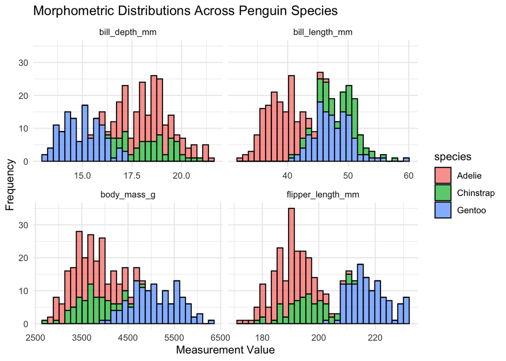

```
## # A tibble: 5 × 3
## # Groups:   species [3]
##   species   island    mean_mass
##   <fct>     <fct>         <dbl>
## 1 Adelie    Biscoe        3710.
## 2 Adelie    Dream         3688.
## 3 Adelie    Torgersen     3706.
## 4 Chinstrap Dream         3733.
## 5 Gentoo    Biscoe        5076.
```

```
## # A tibble: 3 × 4
## # Groups:   species [3]
##   species   Biscoe Dream Torgersen
##   <fct>      <dbl> <dbl>     <dbl>
## 1 Adelie     3710. 3688.     3706.
## 2 Chinstrap    NA  3733.       NA
## 3 Gentoo     5076.   NA        NA
```

### Section 2.7: Separating and Uniting Data Tables

```
## # A tibble: 6 × 3
##   country      year rate
##   <chr>       <dbl> <chr>
## 1 Afghanistan  1999 745/19987071
## 2 Afghanistan  2000 2666/20595360
## 3 Brazil       1999 37737/172006362
## 4 Brazil       2000 80488/174504898
## 5 China        1999 212258/1272915272
## 6 China        2000 213766/1280428583
```

```
## # A tibble: 6 × 4
##   country      year cases  population
##   <chr>       <dbl> <chr>  <chr>
## 1 Afghanistan  1999 745    19987071
## 2 Afghanistan  2000 2666   20595360
## 3 Brazil       1999 37737  172006362
## 4 Brazil       2000 80488  174504898
## 5 China        1999 212258 1272915272
## 6 China        2000 213766 1280428583
```

```
## # A tibble: 6 × 4
##   country      year cases  population
##   <chr>       <dbl> <chr>  <chr>
## 1 Afghanistan  1999 745    19987071
## 2 Afghanistan  2000 2666   20595360
## 3 Brazil       1999 37737  172006362
## 4 Brazil       2000 80488  174504898
## 5 China        1999 212258 1272915272
## 6 China        2000 213766 1280428583
```

```
## # A tibble: 6 × 4
##   country      year  cases population
##   <chr>       <dbl>  <int>      <int>
## 1 Afghanistan  1999    745   19987071
## 2 Afghanistan  2000   2666   20595360
## 3 Brazil       1999  37737  172006362
## 4 Brazil       2000  80488  174504898
## 5 China        1999 212258 1272915272
## 6 China        2000 213766 1280428583
```

```
## # A tibble: 6 × 4
##   country     century year  rate
##   <chr>       <chr>   <chr> <chr>
## 1 Afghanistan 19      99    745/19987071
## 2 Afghanistan 20      00    2666/20595360
## 3 Brazil      19      99    37737/172006362
## 4 Brazil      20      00    80488/174504898
## 5 China       19      99    212258/1272915272
## 6 China       20      00    213766/1280428583
```

Can use unite() to combine multiple columns into a single column

```
## # A tibble: 6 × 4
##   country     century year  rate
##   <chr>       <chr>   <chr> <chr>
## 1 Afghanistan 19      99    745/19987071
## 2 Afghanistan 20      00    2666/20595360
## 3 Brazil      19      99    37737/172006362
## 4 Brazil      20      00    80488/174504898
## 5 China       19      99    212258/1272915272
## 6 China       20      00    213766/1280428583
```

```
## # A tibble: 6 × 3
##   country     new   rate
##   <chr>       <chr> <chr>
## 1 Afghanistan 1999  745/19987071
## 2 Afghanistan 2000  2666/20595360
## 3 Brazil      1999  37737/172006362
## 4 Brazil      2000  80488/174504898
## 5 China       1999  212258/1272915272
## 6 China       2000  213766/1280428583
```

### Section 2.8: Wrangling Strings and Dates

Before we merge data sets or plot timelines, we need to standardise our text strings and date-times - can use stringr for text and lubridate for dates (in the tidyverse package).

#### EXAMPLE: Standardising Text

```
## # A tibble: 5 × 2
##   site_id          site_clean
##   <chr>            <chr>
## 1 " Nelly Bay"     nelly_bay
## 2 "nelly_bay"      nelly_bay
## 3 "NELLY BAY"      nelly_bay
## 4 " Geoffrey_Bay " geoffrey_bay
## 5 "geoffrey bay"   geoffrey_bay
```

#### EXAMPLE: Standardising Date-Time

```
## [1] TRUE
```

```
## # A tibble: 3 × 3
##   raw_time            temperature true_time
##   <chr>                     <dbl> <dttm>
## 1 14-05-2026 08:30:00        24.5 2026-05-14 08:30:00
## 2 14-05-2026 08:45:00        24.6 2026-05-14 08:45:00
## 3 14-05-2026 09:00:00        24.4 2026-05-14 09:00:00
```

Once a column is a recognised datetime object, ggplot2 will automatically understand how to format the x-axis chronologically, and you can easily extract specific components (e.g., using month(true_time) to get the month integer).

### Section 2.9: Relational Data: Joining Tables

Sometimes you may have data split across two tables for simplification reasons (e.g., location_id in one table, specific GPS way points in another). Can use dplyr package to join the tables.

```
## # A tibble: 4 × 5
##   site_code species count zone                   lat
##   <chr>     <chr>   <dbl> <chr>                <dbl>
## 1 NB        Trout       5 Marine National Park -19.2
## 2 GB        Snapper     2 Conservation Park    -19.2
## 3 MI        Trout       1 Habitat Protection   -19.1
## 4 NB        Cod         3 Marine National Park -19.2
```

```
## # A tibble: 4 × 5
##   site_code species count zone                   lat
##   <chr>     <chr>   <dbl> <chr>                <dbl>
## 1 NB        Trout       5 Marine National Park -19.2
## 2 GB        Snapper     2 Conservation Park    -19.2
## 3 MI        Trout       1 Habitat Protection   -19.1
## 4 NB        Cod         3 Marine National Park -19.2
```

```
## # A tibble: 0 × 3
## # ℹ 3 variables: site_code <chr>, species <chr>, count <dbl>
```

### Section 2.10: Handling Missing Data Values

#### Converting legacy errors with na_if()

Some kinds of equipment can place a concrete value to represent a missing value (-99, -999 etc). These concrete values can interfere with mean calculations etc.

```
## # A tibble: 4 × 2
##   depth_m temp_c
##     <dbl>  <dbl>
## 1      10   24.5
## 2      20   24.1
## 3      30   NA
## 4      40   23.5
```

#### Replacing missing values with coalesce()

Sometimes an NA can mean that the value is a known fixed number (most often 0), e.g., a surveyor leaves a cell blank on a clipboard to indicate they saw 0 sharks, but R will import that blank cell as NA. Can use dplyr::coalesce() inside a mutate() to hunt down every NA in a specific column and replace it with 0 (or any other fixed value).

```
## # A tibble: 3 × 2
##   site   shark_count
##   <chr>        <dbl>
## 1 Reef_A           3
## 2 Reef_B           0
## 3 Reef_C           5
```

#### NaN (not a number)

Nan (not a number) means this value you have entered is mathematically impossible. Often occurs when you perform a mathematical operation that has an indeterminate results (e.g., 0/0).

```
## # A tibble: 2 × 4
##   site  catch effort_hours  cpue
##   <chr> <dbl>        <dbl> <dbl>
## 1 Bay_1    10            2     5
## 2 Bay_2     0            0   NaN
```

#### Implicit missing values and the zero-data framework: complete()

In ecology, knowing where a species was not found is just as important as knowing where it was found.

```
## # A tibble: 4 × 3
##   site   species    count
##   <chr>  <chr>      <dbl>
## 1 Reef_1 Pleopardus     2
## 2 Reef_1 Pmaculatus     5
## 3 Reef_2 Pleopardus     0
## 4 Reef_2 Pmaculatus     8
```

#### Nuclear option: drop_na()

If an NA represents a failed reading, and that reading is the core variable of your analysis, you may have no choice but to remove the entire row - can do this using drop_na()

```
## # A tibble: 4 × 2
##     day salinity
##   <int>    <dbl>
## 1     1     35.2
## 2     2     35.1
## 3     3     NA
## 4     4     35.3
```

```
## # A tibble: 3 × 2
##     day salinity
##   <int>    <dbl>
## 1     1     35.2
## 2     2     35.1
## 3     4     35.3
```

### PRACTICAL EXERCISE: PENGUINS, PIVOTS, AND RELATIONAL DATA

In this exercise, you will combine all the skills you have learned in this workshop. You have the clean penguins dataset, but a colleague has just emailed you a supplementary metadata file containing the GPS coordinates and the date the primary weather stations were installed on each island.

Unfortunately, your colleague is not very good at standardising their data entry.

#### EXERCISE ONE: Cleaning messy data

```
## # A tibble: 3 × 3
##   island_name station_install latitude
##   <chr>       <chr>              <dbl>
## 1 " biscoe"   15/01/2003         -64.8
## 2 "Dream "    22-03-2004         -64.7
## 3 "Torgersen" 05/11/2001         -64.8
```

```
## # A tibble: 3 × 4
##   island_name station_install latitude island
##   <chr>       <chr>              <dbl> <chr>
## 1 " biscoe"   15/01/2003         -64.8 Biscoe
## 2 "Dream "    22-03-2004         -64.7 Dream
## 3 "Torgersen" 05/11/2001         -64.8 Torgersen
```

```
## # A tibble: 3 × 5
##   island_name station_install latitude island    true_time
##   <chr>       <chr>              <dbl> <chr>     <date>
## 1 " biscoe"   15/01/2003         -64.8 Biscoe    2003-01-15
## 2 "Dream "    22-03-2004         -64.7 Dream     2004-03-22
## 3 "Torgersen" 05/11/2001         -64.8 Torgersen 2001-11-05
```

#### EXERCISE TWO: THE RELATIONAL JOIN

```
## # A tibble: 344 × 12
##    species island    bill_length_mm bill_depth_mm flipper_length_mm body_mass_g
##    <fct>   <chr>              <dbl>         <dbl>             <int>       <int>
##  1 Adelie  Torgersen           39.1          18.7               181        3750
##  2 Adelie  Torgersen           39.5          17.4               186        3800
##  3 Adelie  Torgersen           40.3          18                 195        3250
##  4 Adelie  Torgersen           NA            NA                  NA          NA
##  5 Adelie  Torgersen           36.7          19.3               193        3450
##  6 Adelie  Torgersen           39.3          20.6               190        3650
##  7 Adelie  Torgersen           38.9          17.8               181        3625
##  8 Adelie  Torgersen           39.2          19.6               195        4675
##  9 Adelie  Torgersen           34.1          18.1               193        3475
## 10 Adelie  Torgersen           42            20.2               190        4250
## # ℹ 334 more rows
## # ℹ 6 more variables: sex <fct>, year <int>, island_name <chr>,
## #   station_install <chr>, latitude <dbl>, true_time <date>
```

#### EXERCISE THREE: THE WIDE SUMMARY MATRIX

```
## # A tibble: 342 × 12
##    species island    bill_length_mm bill_depth_mm flipper_length_mm body_mass_g
##    <fct>   <chr>              <dbl>         <dbl>             <int>       <int>
##  1 Adelie  Torgersen           39.1          18.7               181        3750
##  2 Adelie  Torgersen           39.5          17.4               186        3800
##  3 Adelie  Torgersen           40.3          18                 195        3250
##  4 Adelie  Torgersen           36.7          19.3               193        3450
##  5 Adelie  Torgersen           39.3          20.6               190        3650
##  6 Adelie  Torgersen           38.9          17.8               181        3625
##  7 Adelie  Torgersen           39.2          19.6               195        4675
##  8 Adelie  Torgersen           34.1          18.1               193        3475
##  9 Adelie  Torgersen           42            20.2               190        4250
## 10 Adelie  Torgersen           37.8          17.1               186        3300
## # ℹ 332 more rows
## # ℹ 6 more variables: sex <fct>, year <int>, island_name <chr>,
## #   station_install <chr>, latitude <dbl>, true_time <date>
```

```
##       species       island          bill_length_mm  bill_depth_mm
##  Adelie   :151   Length:342         Min.   :32.10   Min.   :13.10
##  Chinstrap: 68   Class :character   1st Qu.:39.23   1st Qu.:15.60
##  Gentoo   :123   Mode  :character   Median :44.45   Median :17.30
##                                     Mean   :43.92   Mean   :17.15
##                                     3rd Qu.:48.50   3rd Qu.:18.70
##                                     Max.   :59.60   Max.   :21.50
##  flipper_length_mm  body_mass_g       sex           year
##  Min.   :172.0     Min.   :2700   female:165   Min.   :2007
##  1st Qu.:190.0     1st Qu.:3550   male  :168   1st Qu.:2007
##  Median :197.0     Median :4050   NA's  :  9   Median :2008
##  Mean   :200.9     Mean   :4202                Mean   :2008
##  3rd Qu.:213.0     3rd Qu.:4750                3rd Qu.:2009
##  Max.   :231.0     Max.   :6300                Max.   :2009
##  island_name        station_install       latitude        true_time
##  Length:342         Length:342         Min.   :-64.81   Min.   :2001-11-05
##  Class :character   Class :character   1st Qu.:-64.81   1st Qu.:2003-01-15
##  Mode  :character   Mode  :character   Median :-64.76   Median :2003-01-15
##                                        Mean   :-64.77   Mean   :2003-04-16
##                                        3rd Qu.:-64.73   3rd Qu.:2004-03-22
##                                        Max.   :-64.73   Max.   :2004-03-22
```

```
## # A tibble: 3 × 4
## # Groups:   species [3]
##   species   Biscoe Dream Torgersen
##   <fct>      <int> <int>     <int>
## 1 Adelie      4775  4650      4700
## 2 Chinstrap     NA  4800        NA
## 3 Gentoo      6300    NA        NA
```

### Section 2.12: Keystone Exercise: Estuary Fish Survey - Data Rescue Mission

See MB5370_Workshop_2_Keystone for exercise.